# Drawing Analyses – Main figures and Inferential Stats

Bria Long

started 5/8/2019, finalized 7/2023

# Libraries and setup

## Load data

### Import recognition data from each run of recoggames: here, animalgame & vehiclegame

```r
#
animal_game <- read.csv(here::here("data/recognition_data/behavioral_data/animalgame.csv")) %>%
  as_tibble() %>%
  mutate(exp = 'animalgame') %>%
  select(-X)
#
vehicle_game <- read.csv(here::here("data/recognition_data/behavioral_data/vehiclegame.csv")) %>%
  as_tibble() %>%
  mutate(exp = 'vehiclegame') %>%
  select(-X)

biganimal_game <- read.csv(here::here("data/recognition_data/behavioral_data/biganimalgame.csv")) %>%
  as_tibble() %>%
  mutate(exp = 'biganimalgame') %>%
  select(-X)

object_game <- read.csv(here::here("data/recognition_data/behavioral_data/objectgame.csv")) %>%
  as_tibble() %>%
  mutate(exp = 'objectgame') %>%
  select(-X)

recog_data <- animal_game %>%
  full_join(vehicle_game)%>%
  full_join(biganimal_game) %>%
  full_join(object_game)

## make copy for editing
orig_d  <- recog_data
d <- recog_data
```

### Make variables correct types in dataset

```r
# make similar levels
d$clicked_category = as.factor(d$clicked_category)
d$intended_category = factor(d$intended_category, levels=levels(d$clicked_category))

# compute accurcy
d <- d %>%
  mutate(correct_or_not = (clicked_category == intended_category))  %>%
  mutate(recognizer_age_numeric = str_split_fixed(recognizer_age, 'age',2)[,2]) %>%
  mutate(recognizer_age_numeric =  as.numeric(recognizer_age_numeric))


d$recognizer_age <- factor(d$recognizer_age, levels = c('age2','age3','age4','age5','age6','age7','age8','age9','age10','adult'))
```

## Data filtering

### Filter non-compliant subjects & trials:

```r
##Filter out adults, those that didn't get past more than 1 real trial, and trials with RTs that are way too long or short
adults <- d %>%
  filter(recognizer_age == 'adult')

didnt_start <- d %>%
  group_by(sessionId) %>%
  mutate(count_trials = max(trial_num)) %>%
  filter(count_trials < 5)

# do actual filtering here
d <- d %>%
  filter(!sessionId %in% didnt_start$sessionId) %>%
  filter(!sessionId %in% adults$sessionId) %>%
  filter(!recognizer_age=='age2') %>%
  filter(RT>100 & RT<10000) # super long or super short trial
```

## Drawings recognized per exp

```r
drawings_per_exp <- d %>%
  group_by(exp) %>%
  summarize(num_drawings_seen = length(unique(sketch_path)))
```

### Calculate performance on photo catch trials; visualize for each subject; compile list of off-task subjects

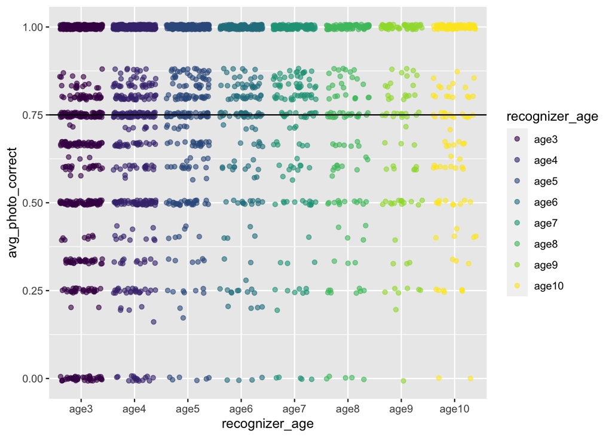

```r
# threshold : 75% correct
threshold=.75

# compute avg correct photo trials for each subject
photo_correct <- d %>%
  group_by(sessionId,recognizer_age) %>%
  filter(producer_age == "photo") %>%
  summarize(avg_photo_correct = mean(correct_or_not))

# visualize these data by each age group
ggplot(photo_correct, aes(x=recognizer_age, y=avg_photo_correct, col=recognizer_age)) +
  geom_jitter(alpha=.6) +
  scale_color_viridis(discrete=TRUE) +
  geom_hline(yintercept=threshold)
```

```r
# make a list of the subjects who don't meet our threshold
bad_subs <- photo_correct %>%
  filter(avg_photo_correct < threshold) ## includes subjects who got 75% correct, excludes all those below
```

### Filter out subs who don’t meet photo correct threshold

```r
# filter bad subs
d <- d %>%
  filter(!sessionId %in% bad_subs$sessionId)

# check that we did this right
photo_trials_by_sub <- d %>%
  filter(producer_age == 'photo') %>%
  group_by(sessionId) %>%
  summarize(avg_correct = mean(correct_or_not))

# make sure this is true.
assert_that(sum(photo_trials_by_sub$avg_correct<threshold)==0)
```

```
## [1] TRUE
```

### Finally, filter kids that didn’t have valid trials on both photo/sketch trials

```r
cor_by_trial_type <- d %>%
  mutate(photo_or_not = (producer_age == 'photo')) %>%
  group_by(photo_or_not,sessionId) %>%
  summarize(count_cor = sum(correct_or_not), count_items = n(), avg_correct = count_cor / count_items)

only_one_type <- cor_by_trial_type %>%
  group_by(sessionId) %>%
  summarize(count_ids = n()) %>%
  filter(count_ids == 1)

# filter these subjects
d <- d %>%
  filter(!sessionId %in% only_one_type$sessionId)
```

## Create subset of high performers for supplemental analyses

```r
high_performers_criteria_1 <- photo_correct %>%
  filter(avg_photo_correct == 1)
```

```r
high_performers_criteria_2 <- d %>%
  group_by(sessionId,recognizer_age) %>%
  filter(producer_age != "photo") %>%
  summarize(avg_drawing_correct = mean(correct_or_not)) %>%
  filter(avg_drawing_correct >= .5)
```

```r
high_performers <- high_performers_criteria_1 %>%
  select(sessionId) %>%
  filter(sessionId %in% high_performers_criteria_2$sessionId)
```

How many high performers do we have?

```r
length(unique(high_performers$sessionId))
```

```
## [1] 649
```

```r
high_performers_descriptives <- d %>%
  filter(sessionId %in% high_performers$sessionId) %>%
  group_by(recognizer_age) %>%
  summarize(num_kids = length(unique(sessionId))) %>%
  kable()
```

### Calculate number of trials per kid (not adult) after these exclusions and report exclusions

```r
num_trials_per_kid <- d %>%
  # filter(!sessionId %in% adults$sessionId) %>% # exclude adults (prereg code, error)
  filter(recognizer_age != "adult") %>% # exclude adults
  group_by(sessionId) %>%
  summarize(max_trials = max(trial_num)) %>%
  summarize(average_trials = mean(max_trials))

num_kids_per_exp <- d %>%
  filter(recognizer_age != "adult") %>% # exclude adults
  group_by(exp,recognizer_age) %>%
  summarize(num_subs = length(unique(sessionId)))

##
```

First, we excluded children who started the game but did not complete more than 1 trial after the practice trials (N = 1068 participants) and the 238 adults who participated. We also excluded all trials with RTs slower than 10s or faster than 100ms, judging these to be off-task responses. Next, we excluded participants on the basis of their performance on practice and catch trials; given that these catch trials presented a very easy recognition task, we excluded participants who did not acheive at least 75% accuracy on these trials (N= 795). The remaining 1789 who met this criterion completed an average of 21.69 trials. On total, we analyzed 36615 trials where children recognized each others drawings.

### Exclusion rates in each age bin; see that we are mostly filtering out young kids not on task.

```r
bad_subs_descriptives <- orig_d %>%
  filter(sessionId %in% bad_subs$sessionId) %>%
  group_by(sessionId) %>%
  summarize(count_trials = n(), recognizer_age = recognizer_age[1]) %>%
  group_by(recognizer_age) %>%
  summarize(count_subs = n(), avg_trials = mean(count_trials))

kable(bad_subs_descriptives)
```

| recognizer_age | count_subs | avg_trials |
| --- | --- | --- |
| age10 | 46 | 19.19565 |
| age3 | 270 | 14.37778 |
| age4 | 180 | 16.18889 |
| age5 | 103 | 21.38835 |
| age6 | 60 | 20.16667 |
| age7 | 50 | 17.58000 |
| age8 | 49 | 17.34694 |
| age9 | 37 | 15.45946 |

### Calculate number of subs left in each age

```r
d %>%
  group_by(recognizer_age) %>%
  summarize(num_subs = length(unique(sessionId))) %>%
  kable()
```

| recognizer_age | num_subs |
| --- | --- |
| age3 | 329 |
| age4 | 408 |
| age5 | 301 |
| age6 | 227 |
| age7 | 188 |
| age8 | 131 |
| age9 | 84 |
| age10 | 121 |

### Calculate number of trials per kid (not adult) after these exclusions and report exclusions

```r
num_trials_per_kid <- d %>%
  # filter(!sessionId %in% adults$sessionId) %>% # exclude adults (prereg code, error)
  filter(recognizer_age != "adult") %>% # exclude adults
  group_by(sessionId) %>%
  summarize(max_trials = max(trial_num)) %>%
  summarize(average_trials = mean(max_trials))

num_kids_per_exp <- d %>%
  filter(recognizer_age != "adult") %>% # exclude adults
  group_by(exp,recognizer_age) %>%
  summarize(num_subs = length(unique(sessionId)))

##
```

First, we excluded children who started the game but did not complete more than 1 trial after the practice trials (N = 1068 participants) and the 238 adults who participated. We also excluded all trials with RTs slower than 10s or faster than 100ms, judging these to be off-task responses. Next, we excluded participants on the basis of their performance on practice and catch trials; given that these catch trials presented a very easy recognition task, we excluded participants who did not acheive at least 75% accuracy on these trials (N= 795). The remaining 1789 who met this criterion completed an average of 21.69 trials. On total, we analyzed 36615 trials where children recognized each others drawings.

### Exclusion rates in each age bin; see that we are mostly filtering out young kids not on task.

```r
bad_subs_descriptives <- orig_d %>%
  filter(sessionId %in% bad_subs$sessionId) %>%
  group_by(sessionId) %>%
  summarize(count_trials = n(), recognizer_age = recognizer_age[1]) %>%
  group_by(recognizer_age) %>%
  summarize(count_subs = n(), avg_trials = mean(count_trials))

kable(bad_subs_descriptives)
```

| recognizer_age | count_subs | avg_trials |
| --- | --- | --- |
| age10 | 46 | 19.19565 |
| age3 | 270 | 14.37778 |
| age4 | 180 | 16.18889 |
| age5 | 103 | 21.38835 |
| age6 | 60 | 20.16667 |
| age7 | 50 | 17.58000 |
| age8 | 49 | 17.34694 |
| age9 | 37 | 15.45946 |

### Calculate number of subs left in each age

```r
d %>%
  group_by(recognizer_age) %>%
  summarize(num_subs = length(unique(sessionId))) %>%
  kable()
```

| recognizer_age | num_subs |
| --- | --- |
| age3 | 329 |
| age4 | 408 |
| age5 | 301 |
| age6 | 227 |
| age7 | 188 |
| age8 | 131 |
| age9 | 84 |
| age10 | 121 |

## First set of descriptives

### How are recognizers doing on photo trials aross age? Looks pretty flat.

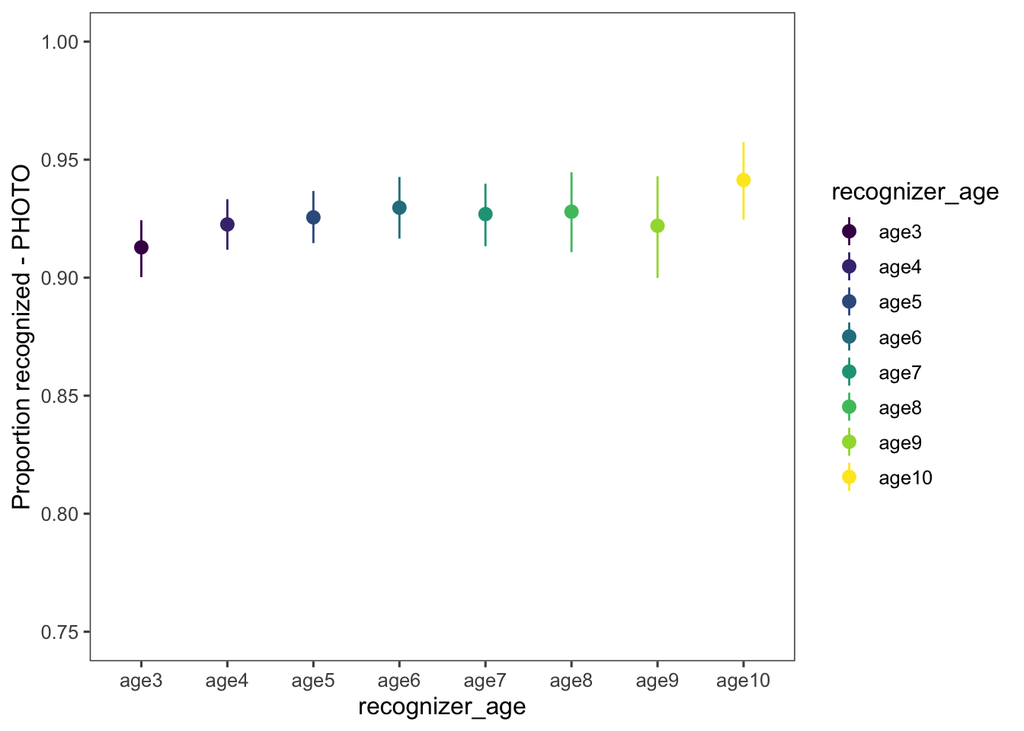

```r
by_recognizer_photo <- d %>%
  group_by(recognizer_age) %>%
  filter(producer_age == 'photo') %>%
  group_by(sessionId,recognizer_age) %>%
  summarize(indiv_photo_correct = mean(correct_or_not)) %>% # average first over individual participants
  group_by(recognizer_age) %>%
  multi_boot_standard(col = 'indiv_photo_correct')

by_recognizer_photo$recognizer_age <- factor(by_recognizer_photo$recognizer_age, levels = c('age2','age3','age4','age5','age6','age7','age8','age9','age10','adult'))

ggplot(by_recognizer_photo,aes(x=recognizer_age, y=mean, col = recognizer_age)) +
  geom_pointrange(aes(ymin = ci_lower, ymax = ci_upper)) +
  scale_color_viridis(discrete = "TRUE") +
  ylab('Proportion recognized - PHOTO') +
  ylim(.75,1) + # can't be lower than 75% correct or higher than 1
  theme_few()
```

### Look at overall recognition by recognizer age; looks like we should exclude 2 year-olds.

```r
by_recognizer_age <- d %>%
  filter(producer_age != 'photo') %>%
  group_by(sessionId, recognizer_age_numeric) %>%
  summarize(avg_correct = mean(correct_or_not), num_trials = n()) %>%
  filter(num_trials > 5) %>%
  group_by(recognizer_age_numeric) %>%
  multi_boot_standard(col = 'avg_correct')

by_each_recognizer <- d %>%
  group_by(sessionId,recognizer_age_numeric) %>%
  filter(producer_age != 'photo') %>%
  summarize(avg_correct = mean(correct_or_not), num_trials = n()) %>%
  filter(num_trials > 5)
```

# Examine recognition by age

Figures for paper in step 6

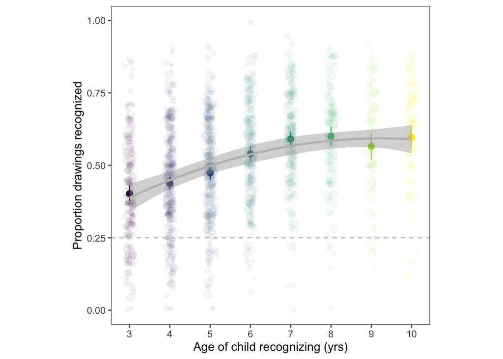

```r
base_size_chosen=12
ggplot(by_recognizer_age,aes(x=recognizer_age_numeric, y=mean, col = recognizer_age_numeric)) +
  theme_few(base_size = base_size_chosen) +
  geom_pointrange(aes(ymin = ci_lower, ymax = ci_upper)) +
  geom_jitter(data = by_each_recognizer, aes(x=recognizer_age_numeric, y=avg_correct, size=num_trials), alpha=.05, width=.1, height=.01) +
  scale_color_viridis(discrete = "FALSE") +
  scale_size_area(max_size = 5) +
  ylab('Proportion drawings recognized') +
  ylim(0, 1) +
  geom_hline(yintercept = .25, linetype = 'dashed', color='grey')  +
  geom_smooth(color = 'grey', span=10) +
  xlab('Age of child recognizing (yrs)') +
  theme(legend.position='none', aspect.ratio = 1) +
  # labs(title='Drawing recognition by age') +
  scale_x_continuous(breaks = seq(3,10,1))
```

```r
# ggsave('figures_out/figure5a_recognition_by_recognizer_age.pdf',width=3, height=3, units='in')

# write_csv(by_recognizer_age, file = here::here('data/figures_csvs/figure5a_recognition_by_recognizer_age.csv'))
```

## filter recognition data to just kids and wrangle variables

```r
kids_sketches_d <- d %>%
  filter(producer_age != 'photo') %>% # don't look at photo trials
  filter(recognizer_age != 'age2') %>%  # or 2-yr-olds
  mutate(recognizer_age_numeric = as.numeric(str_split_fixed(recognizer_age,'age',2)[,2])) %>%
  mutate(recognizer_age_group = cut(recognizer_age_numeric, c(2.9, 4, 6, 8, 10.1), labels = c("3-4 yrs","5-6 yrs","7-8 yrs","9-10 yrs"))) %>%
  mutate(recognizer_age_group_numeric = cut(recognizer_age_numeric, c(2.9, 4, 6, 8, 10.1), labels=c(3,5,7,9))) %>%
  mutate(recognizer_age_group_numeric = as.numeric(recognizer_age_group_numeric))
```

### And wrangle sketch paths so can be joined with classification data outputs

```r
kids_sketches_d <- kids_sketches_d %>%
  mutate(sketch_path = as.factor(str_split_fixed(sketch_path,'/',2)[,2])) %>%
  mutate(sketch_path = as.factor(str_split_fixed(sketch_path,'.png',2)[,1]))
```

## Compute and plot recognition by sketch distinctiveness

We expect that the distintiveness of each drawing will be a major factor in how well it is recognized, and, further, that older children will be more sensitive to the presence of these distinctive features.

### Import classifications data (4-way classifications separetly for each run of recoggames)

```r
c_vehiclegame <- read.csv(here::here("data/recognition_data/model_classifications/classification-outputs-vehiclegame_C_0.1_460.csv")) %>%
  as_tibble() %>%
  select(-X.1, -X) %>%
  mutate(denom = (airplane_prob + train_prob + boat_prob + car_prob) - target_label_prob) %>%
  mutate(log_odds = log(target_label_prob / denom)) %>% ## compute log odd probability
  mutate(exp='vehiclegame')

# now read it and join with other classifications
c_animalgame <- read.csv(here::here("data/recognition_data/model_classifications/classification-outputs-animalgame_C_0.1_560.csv")) %>%
  as_tibble() %>%
  select(-X.1, -X) %>%
  mutate(denom = (dog_prob + fish_prob + rabbit_prob + bird_prob) - target_label_prob) %>%
  mutate(log_odds = log(target_label_prob / denom)) %>%
  mutate(exp='animalgame')

#
c_biganimalgame <- read.csv(here::here("data/recognition_data/model_classifications/classification-outputs-biganimalgame_C_0.1_600.csv")) %>%
  as_tibble() %>%
  select(-X.1, -X) %>%
  mutate(denom = (bear_prob + sheep_prob + camel_prob + tiger_prob) - target_label_prob) %>%
  mutate(log_odds = log(target_label_prob / denom)) %>%
  mutate(exp='animalgame')

# now read it and join with other classifications
c <- read.csv(here::here("data/recognition_data/model_classifications/classification-outputs-objectgame_C_0.1_500.csv")) %>%
  as_tibble() %>%
  select(-X.1, -X) %>%
  mutate(denom = (bottle_prob + lamp_prob + hat_prob + cup_prob) - target_label_prob) %>%
  mutate(log_odds = log(target_label_prob / denom)) %>%
  mutate(exp='objectgame') %>%
  full_join(c_vehiclegame) %>%
  full_join(c_animalgame) %>%
  full_join(c_biganimalgame) %>%
  mutate(sketch_path = paste0(target_label,'_','sketch_age',age,'_cdm_',session_id)) %>%
  mutate(sketch_path = as.factor(sketch_path))  %>%
  rename(model_correct_or_not = correct_or_not)
```

## Compute distincitveness bins (used for visualizations) join classifications & recognition data

```r
num_bins=10

## compute bins for distinctiveness
sketch_by_distinctiveness <- c %>%
  mutate(distinct_index = ntile(log_odds,num_bins)) %>% ## compute bins based on log odds over entire dataset
  select(sketch_path, distinct_index, log_odds, model_correct_or_not)

## join distinctiveness bins for each sketch in dataset
all_joined <- kids_sketches_d %>%
  left_join(sketch_by_distinctiveness) %>%
  filter(!is.na(model_correct_or_not))  # a few sketches in animalgame were accidentally included that should have been filtered (contained words, were scribbles and so don't have corresponding model classifications)

all_joined <- all_joined %>%
  mutate(producer_age_numeric = as.numeric(str_split_fixed(producer_age,'age',2)[,2]))
```

# Distinctivenss by age interaction

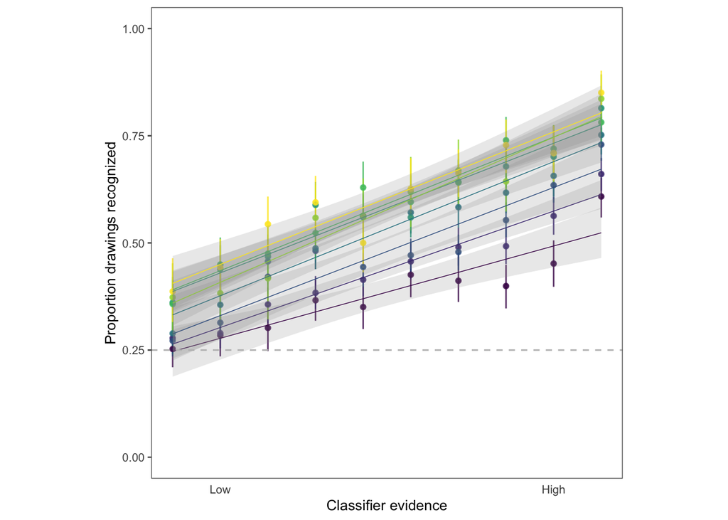

```r
## Panel B in ms figure
distinct_by_age <- all_joined %>%
  group_by(recognizer_age_numeric, distinct_index) %>%
  multi_boot_standard(col='correct_or_not') %>%
  group_by(distinct_index) %>%
  mutate(recognizer_age_name = paste0(as.character(recognizer_age_numeric), '-year-olds'))

 ggplot(distinct_by_age, aes(x=distinct_index, y=mean, col=as.factor(recognizer_age_numeric))) +
  geom_pointrange(aes(ymin = ci_lower, ymax = ci_upper), alpha=.8, size=.2) +
  geom_smooth(alpha=.2, span=4, method='lm', size=.25) +
  # facet_wrap(~recognizer_age_numeric, nrow=2) +
  theme_few(base_size = 10) +
  xlab('Classifier evidence') +
  ylab('Proportion drawings recognized') +
  theme(legend.position='none') +
  scale_color_viridis(discrete=TRUE) +
  scale_x_continuous(
    breaks=c(2,9),
    labels=c(' Low ',' High ')
        ) +
  theme(axis.ticks.x=element_blank(), aspect.ratio=1) +
  geom_hline(yintercept=.25, linetype='dashed',color='grey') +
  ylim(0,1)
```

```r
# ggsave(here::here('data/figures_out/Figure6a-v1-_distinct_by_age.pdf'), height=3,  units='in')

# write_csv(distinct_by_age, file = here::here('data/figures_csvs/Figure6a-v1-distinct_by_age.csv'))
```

# Supplemental

## Producer age x recognizer age

```r
crossed_design <-  all_joined %>%
  group_by(sessionId, recognizer_age_numeric, producer_age_numeric) %>%
  summarize(avg_correct = mean(correct_or_not), num_participants=n()) %>%
  group_by(recognizer_age_numeric, producer_age_numeric) %>%
  multi_boot_standard(col='avg_correct')
```

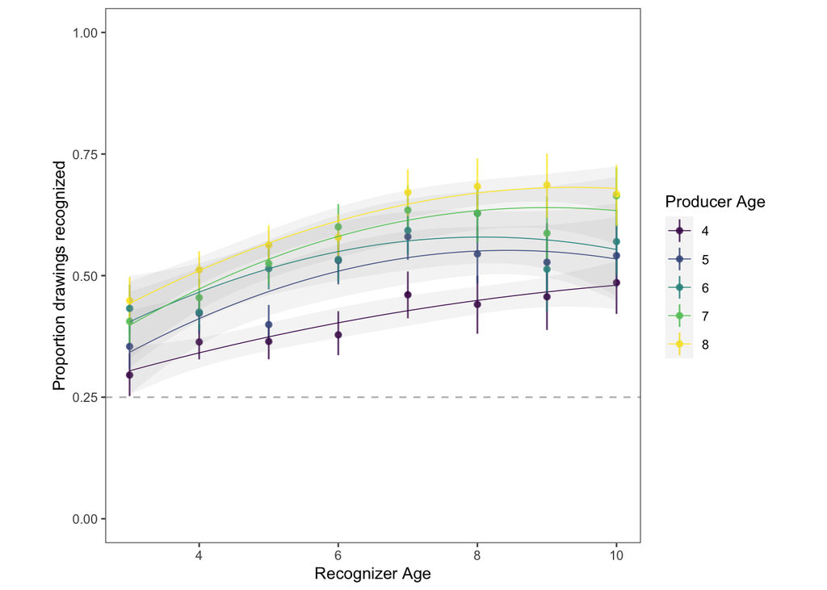

```r
 ggplot(crossed_design, aes(x=recognizer_age_numeric, y=mean, col=as.factor(producer_age_numeric))) +
  geom_pointrange(aes(ymin = ci_lower, ymax = ci_upper), alpha=.8, size=.2) +
  geom_smooth(alpha=.1,  span=4, size=.25) +
  # facet_wrap(~category, nrow= d2) +
  theme_few(base_size = 10) +
  xlab('Producer age') +
  ylab('Proportion drawings recognized') +
  theme(legend.position='right') +
  scale_color_viridis(discrete=TRUE, name = 'Producer Age') +
  # scale_x_continuous(breaks=c(2,10)) +
  xlab ('Recognizer Age') +
  theme(aspect.ratio=1) +
  geom_hline(yintercept=.25, linetype='dashed',color='grey') +
  ylim(0,1)
```

```r
ggsave(here::here('data/figures_out/Appendix_B2_producer_by_recognizer_age.pdf'),units='in', width=4, height=3)

write_csv(crossed_design, file = here::here('data/figures_csvs/Appendix_B2_producer_by_recognizer_age.csv'))
```

### Look at item effects

```r
both_category <- all_joined %>%
  filter(producer_age != 'photo') %>%
  group_by(recognizer_age_numeric,intended_category) %>%
  multi_boot_standard(col = 'correct_or_not')  %>%
  mutate(category = factor(intended_category, levels = c("bird", "fish", "rabbit","dog" ,"sheep","tiger" ,"camel" , "bear", "cup","lamp", "hat","bottle", "car", "boat","airplane","train")))


data_per_bin <- all_joined %>%
  group_by(recognizer_age_numeric,intended_category) %>%
  summarize(num_trials = n())

both_category <- both_category %>%
  left_join(data_per_bin)
```

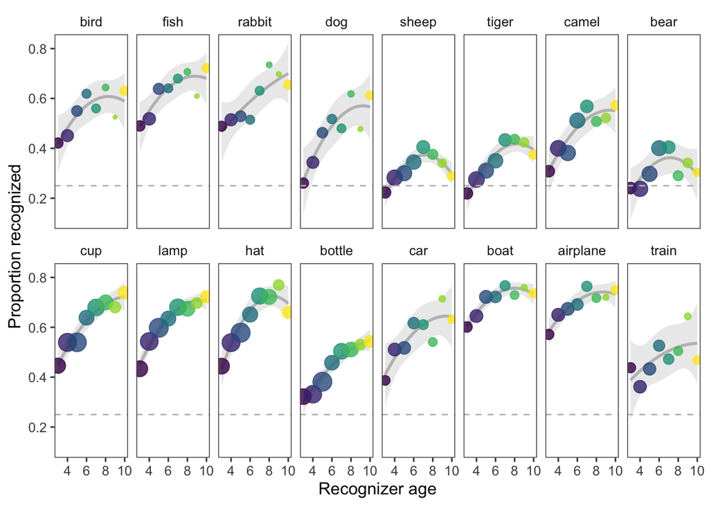

```r
ggplot(both_category,aes(x=recognizer_age_numeric, y=mean, col=recognizer_age_numeric, size=scale(num_trials))) +
  theme_few() +
  geom_smooth(span=20, color='grey', alpha=.2) +
  geom_point(alpha=.8) +
  ylab('Proportion recognized') +
  xlab('Recognizer age') +
  facet_wrap(~category, nrow=2) +
  geom_hline(yintercept=.25, color='grey', linetype='dashed', aes(weight = num_trials)) +
  scale_color_viridis(discrete=FALSE, name='Recognizer Age')  +
  theme(legend.position='none')
```

```r
ggsave(here::here('data/figures_out/Appendix_B3_recognition_by_category.pdf'), units='in', width=7.5)

write_csv(both_category, file = here::here('data/figures_csvs/Appendix_B3_recognition_by_category.csv'))
```

# Inferential statistics

### Examine how distinctivenss vs age group interact in glmer

```r
# make sure
all_joined <-all_joined %>%
  filter(!producer_age %in% c('photo'))

model_glmer <- glmer(correct_or_not ~ scale(log_odds)*scale(recognizer_age_numeric) + (scale(log_odds)|intended_category) + (1|sessionId),  data = all_joined, family='binomial')

cis = confint(model_glmer, method='Wald')
```

```r
summary_model <- summary(model_glmer)

summary_table_complete <- cbind(Estimate = sprintf("%.3f",round(summary_model$coefficients[, "Estimate"],3)),
                                `Std. Error` = sprintf("%.3f",round(summary_model$coefficients[, "Std. Error"],3)),
                                `z value` = sprintf("%.3f",round(summary_model$coefficients[, "z value"],3)),
                                `Pr(>|z|)` = format.pval(summary_model$coefficients[, "Pr(>|z|)"],eps=0.0001,scientific = FALSE, digits=2),
                                 `2.5 % CI` = sprintf("%.3f",round(cis[5:8, 1],3)),
                                `97.5 % CI` = sprintf("%.3f",round(cis[5:8, 2],3)))

rownames(summary_table_complete) = c('Intercept','Classifier evidence', 'Recognizer age','Classifier evidence*Recognizer Age')
```

```r
xtable::xtable(summary_table_complete, digits=3, caption ="Model coefficients of a generalized linear mixed-effects model predicting binary visual recognition performance for each drawing as a function of recognizer age and classifier evidence in each drawing that was recognized by children. All predictors were z-scored prior to analysis such that coefficients are standardized and comparable. All significance tests are Wald significance tests based on the coefficient values; these tests are two-tailed. No adjustments were made for multiple comparisons. See \textit{Methods} for model details on model specifications.")
```

```
## % latex table generated in R 4.3.1 by xtable 1.8-4 package
## % Thu Jan 18 15:00:28 2024
## \begin{table}[ht]
## \centering
## \begin{tabular}{rllllll}
##   \hline
##  & Estimate & Std. Error & z value & Pr($>$$|$z$|$) & 2.5 \% CI & 97.5 \% CI \\
##   \hline
## Intercept & 0.050 & 0.121 & 0.412 & 0.68 & -0.187 & 0.287 \\
##   Classifier evidence & 0.477 & 0.046 & 10.405 & $<$0.0001 & 0.387 & 0.566 \\
##   Recognizer age & 0.317 & 0.019 & 16.777 & $<$0.0001 & 0.280 & 0.354 \\
##   Classifier evidence*Recognizer Age & 0.062 & 0.014 & 4.246 & $<$0.0001 & 0.033 & 0.090 \\
##    \hline
## \end{tabular}
## \caption{Model coefficients of a generalized linear mixed-effects model predicting binary visual recognition performance for each drawing as a function of recognizer age and classifier evidence in each drawing that was recognized by children. All predictors were z-scored prior to analysis such th…
## \end{table}
```

### Appendix Table B2: Examine how results change with only high performing kids

```r
all_joined_high_perf <- all_joined %>%
  filter(sessionId %in% high_performers$sessionId)


model_glmer_high_performers <- glmer(correct_or_not ~ scale(log_odds)*scale(recognizer_age_numeric) +  (log_odds|intended_category)  + (1|sessionId),  data = all_joined_high_perf, family='binomial')

# out = summary(model_glmer_high_performers)
cis_high_perform = confint(model_glmer_high_performers, method='Wald')
```

```r
summary_model <- summary(model_glmer_high_performers)

summary_table_complete_high_performer <- cbind(Estimate = sprintf("%.3f",round(summary_model$coefficients[, "Estimate"],3)),
                                `Std. Error` = sprintf("%.3f",round(summary_model$coefficients[, "Std. Error"],3)),
                                `z value` = sprintf("%.3f",round(summary_model$coefficients[, "z value"],3)),
                                `Pr(>|z|)` = format.pval(summary_model$coefficients[, "Pr(>|z|)"],eps=0.0001,scientific = FALSE, digits=2),
                                 `2.5 % CI` = sprintf("%.3f",round(cis_high_perform[5:8, 1],3)),
                                `97.5 % CI` = sprintf("%.3f",round(cis_high_perform[5:8, 2],3)))

rownames(summary_table_complete_high_performer) = c('Intercept','Classifier evidence', 'Recognizer age','Classifier evidence*Recognizer Age')
```

```r
xtable::xtable(summary_table_complete_high_performer, digits=3, caption = "Model coefficients of a generalized linear mixed-effects model predicting binary visual recognition performance for each drawing as a function of recognizer age and classifier evidence in each drawing that was recognized by children. All predictors were z-scored prior to analysis such that coefficients are standardized and comparable. All significance tests are Wald significance tests based on the coefficient values; these tests are two-tailed. No adjustments were made for multiple comparisons. See \textit{Methods} for model details on model specifications.")
```

```
## % latex table generated in R 4.3.1 by xtable 1.8-4 package
## % Thu Jan 18 15:00:32 2024
## \begin{table}[ht]
## \centering
## \begin{tabular}{rllllll}
##   \hline
##  & Estimate & Std. Error & z value & Pr($>$$|$z$|$) & 2.5 \% CI & 97.5 \% CI \\
##   \hline
## Intercept & 0.668 & 0.099 & 6.715 & $<$0.0001 & 0.473 & 0.863 \\
##   Classifier evidence & 0.518 & 0.051 & 10.057 & $<$0.0001 & 0.417 & 0.618 \\
##   Recognizer age & 0.141 & 0.023 & 6.190 & $<$0.0001 & 0.096 & 0.185 \\
##   Classifier evidence*Recognizer Age & 0.056 & 0.023 & 2.464 & 0.014 & 0.011 & 0.101 \\
##    \hline
## \end{tabular}
## \caption{Model coefficients of a generalized linear mixed-effects model predicting binary visual recognition performance for each drawing as a function of recognizer age and classifier evidence in each drawing that was recognized by children. All predictors were z-scored prior to analysis such th…
## \end{table}
```

## Supplemental: Visualize model fits by age

```r
model_glmer <- glmer(correct_or_not ~log_odds +  scale(producer_age_numeric)*scale(recognizer_age_numeric) + (scale(producer_age_numeric)|intended_category) + (recognizer_age_numeric|sessionId),  data = all_joined, family='binomial')
out = summary(model_glmer)

round(out$coefficients,3)
```

```
##                                                           Estimate Std. Error
## (Intercept)                                                  0.632      0.125
## log_odds                                                     0.837      0.028
## scale(producer_age_numeric)                                  0.255      0.029
## scale(recognizer_age_numeric)                                0.327      0.021
## scale(producer_age_numeric):scale(recognizer_age_numeric)    0.024      0.014
##                                                           z value Pr(>|z|)
## (Intercept)                                                 5.046    0.000
## log_odds                                                   29.397    0.000
## scale(producer_age_numeric)                                 8.765    0.000
## scale(recognizer_age_numeric)                              15.926    0.000
## scale(producer_age_numeric):scale(recognizer_age_numeric)   1.720    0.085
```

```r
xtable::xtable(summary(out)$coef, digits=3, caption = "Model coefficients of a GLMM predicting visual recognition performance as a function of recognizer age and visual 'distinctiveness' (i.e. log-odds probability of selecting the correct label in logistic regression based on visual features, see Methods).")
```

```
## % latex table generated in R 4.3.1 by xtable 1.8-4 package
## % Thu Jan 18 15:02:51 2024
## \begin{table}[ht]
## \centering
## \begin{tabular}{rrrrr}
##   \hline
##  & Estimate & Std. Error & z value & Pr($>$$|$z$|$) \\
##   \hline
## (Intercept) & 0.632 & 0.125 & 5.046 & 0.000 \\
##   log\_odds & 0.837 & 0.028 & 29.397 & 0.000 \\
##   scale(producer\_age\_numeric) & 0.255 & 0.029 & 8.765 & 0.000 \\
##   scale(recognizer\_age\_numeric) & 0.327 & 0.021 & 15.926 & 0.000 \\
##   scale(producer\_age\_numeric):scale(recognizer\_age\_numeric) & 0.024 & 0.014 & 1.720 & 0.085 \\
##    \hline
## \end{tabular}
## \caption{Model coefficients of a GLMM predicting visual recognition performance as a function of recognizer age and visual 'distinctiveness' (i.e. log-odds probability of selecting the correct label in logistic regression based on visual features, see Methods).}
## \end{table}
```

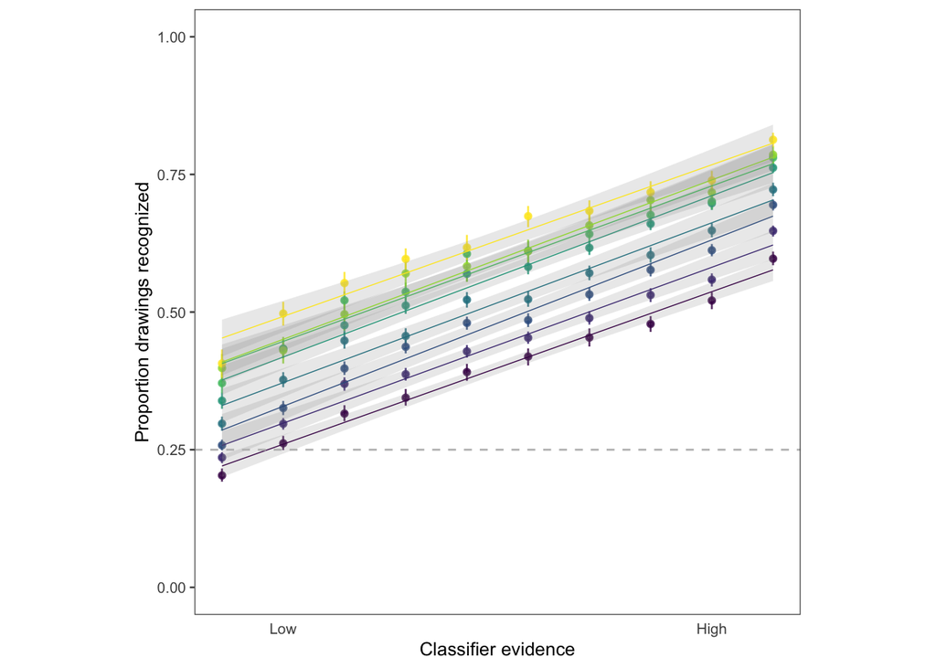

```r
predicted_vals = predict(model_glmer, all_joined, type='response')
all_joined_with_predictions <- all_joined
all_joined_with_predictions$prediction = predicted_vals

distinct_by_age_model_fits <- all_joined_with_predictions %>%
  group_by(recognizer_age_numeric, distinct_index) %>%
  multi_boot_standard(col='prediction') %>%
  group_by(distinct_index) %>%
  mutate(recognizer_age_name = paste0(as.character(recognizer_age_numeric), '-year-olds'))

 ggplot(distinct_by_age_model_fits, aes(x=distinct_index, y=mean, col=as.factor(recognizer_age_numeric))) +
  geom_pointrange(aes(ymin = ci_lower, ymax = ci_upper), alpha=.8, size=.2) +
  geom_smooth(alpha=.2, span=4, method='lm', size=.25) +
  # facet_wrap(~recognizer_age_numeric, nrow=2) +
  theme_few(base_size = 10) +
  xlab('Classifier evidence') +
  ylab('Proportion drawings recognized') +
  theme(legend.position='none') +
  scale_color_viridis(discrete=TRUE) +
  scale_x_continuous(
    breaks=c(2,9),
    labels=c(' Low ',' High ')
        ) +
  theme(axis.ticks.x=element_blank(), aspect.ratio=1) +
  geom_hline(yintercept=.25, linetype='dashed',color='grey') +
  ylim(0,1)
```

**R version 4.3.1 (2023-06-16)**

**Platform:** x86_64-apple-darwin20 (64-bit)

**locale:** en_US.UTF-8||en_US.UTF-8||en_US.UTF-8||C||en_US.UTF-8||en_US.UTF-8

**attached base packages:** *stats*, *graphics*, *grDevices*, *utils*, *datasets*, *methods* and *base*

**other attached packages:** *pander(v.0.6.5)*, *lmerTest(v.3.1-3)*, *lme4(v.1.1-34)*, *Matrix(v.1.6-1)*, *ggthemes(v.4.2.4)*, *viridis(v.0.6.4)*, *viridisLite(v.0.4.2)*, *langcog(v.0.1.9001)*, *assertthat(v.0.2.1)*, *knitr(v.1.43)*, *lubridate(v.1.9.2)*, *forcats(v.1.0.0)*, *stringr(v.1.5.0)*, *dplyr(v.1.1.2)*, *purrr(v.1.0.2)*, *readr(v.2.1.4)*, *tidyr(v.1.3.0)*, *tibble(v.3.2.1)*, *ggplot2(v.3.4.3)* and *tidyverse(v.2.0.0)*

**loaded via a namespace (and not attached):** *tidyselect(v.1.2.0)*, *farver(v.2.1.1)*, *fastmap(v.1.1.1)*, *lazyeval(v.0.2.2)*, *digest(v.0.6.33)*, *rpart(v.4.1.19)*, *timechange(v.0.2.0)*, *lifecycle(v.1.0.3)*, *cluster(v.2.1.4)*, *magrittr(v.2.0.3)*, *compiler(v.4.3.1)*, *rlang(v.1.1.1)*, *Hmisc(v.5.1-1)*, *sass(v.0.4.7)*, *tools(v.4.3.1)*, *utf8(v.1.2.3)*, *yaml(v.2.3.7)*, *data.table(v.1.14.8)*, *labeling(v.0.4.2)*, *htmlwidgets(v.1.6.2)*, *bit(v.4.0.5)*, *here(v.1.0.1)*, *withr(v.2.5.0)*, *foreign(v.0.8-84)*, *numDeriv(v.2016.8-1.1)*, *nnet(v.7.3-19)*, *grid(v.4.3.1)*, *fansi(v.1.0.4)*, *xtable(v.1.8-4)*, *colorspace(v.2.1-0)*, *scales(v.1.2.1)*, *MASS(v.7.3-60)*, *cli(v.3.6.1)*, *crayon(v.1.5.2)*, *rmarkdown(v.2.24)*, *ragg(v.1.2.5)*, *generics(v.0.1.3)*, *rstudioapi(v.0.15.0)*, *tzdb(v.0.4.0)*, *minqa(v.1.2.5)*, *cachem(v.1.0.8)*, *splines(v.4.3.1)*, *parallel(v.4.3.1)*, *base64enc(v.0.1-3)*, *vctrs(v.0.6.3)*, *boot(v.1.3-28.1)*, *jsonlite(v.1.8.7)*, *hms(v.1.1.3)*, *bit64(v.4.0.5)*, *Formula(v.1.2-5)*, *htmlTable(v.2.4.1)*, *systemfonts(v.1.0.4)*, *jquerylib(v.0.1.4)*, *glue(v.1.6.2)*, *nloptr(v.2.0.3)*, *stringi(v.1.7.12)*, *gtable(v.0.3.4)*, *munsell(v.0.5.0)*, *pillar(v.1.9.0)*, *htmltools(v.0.5.6)*, *R6(v.2.5.1)*, *textshaping(v.0.3.6)*, *rprojroot(v.2.0.3)*, *vroom(v.1.6.3)*, *evaluate(v.0.21)*, *lattice(v.0.21-8)*, *highr(v.0.10)*, *backports(v.1.4.1)*, *bslib(v.0.5.1)*, *Rcpp(v.1.0.11)*, *gridExtra(v.2.3)*, *nlme(v.3.1-162)*, *checkmate(v.2.2.0)*, *mgcv(v.1.8-42)*, *xfun(v.0.40)* and *pkgconfig(v.2.0.3)*